# Ford GoBike Visualization Project

##### (Part 2 - Presentation)

#### **by** Manar Abdullah Al Rawahi

#### For the **Udacity Visualization Project** Conducted on **2024**

## Investigation Overview

> The main goal of this project is to analyze the Ford GoBike dataset to understand user behaviors, trip patterns, and demographics. By focusing on key features such as trip duration, start and end stations, user type, age group, and bike-sharing participation, the investigation sought to uncover how different user groups interact with the bike-sharing service.

## Dataset Overview

> The dataset captures trip data from the Ford GoBike bike-sharing program, with 174,952 trips recorded after cleaning and 31 columns detailing user behavior and trip characteristics along with additional columns after transformation. Key features include trip duration (in seconds), start/end times, and start/end stations (with geographic coordinates). The dataset also provides demographic data such as user type (subscriber vs. customer), member birth year, and gender, allowing for analysis of trip patterns across different user groups and locations. Data types consist of a mix of numerical and categorical values, which support comprehensive exploration of bike usage trends.

## Trip Duration Across Weekdays by User Type

> This visual introduces the overall user behavior between customers and subscribers. It shows how customers take longer trips on weekends, while subscribers have more consistent, shorter trips across the week.

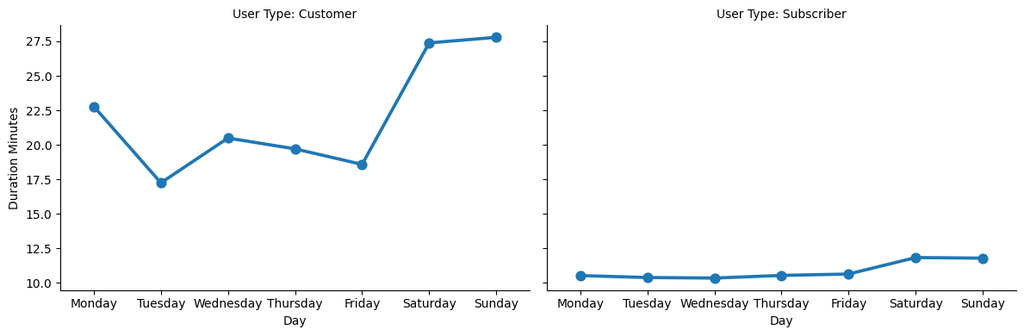